# Lab 1

# Assignment 1

## Outliers finding functin

```r
#' Function of getting outliers' indices
#'
#' @param column A vector of data
#'
#' @returns Indices of outlying observations
func1 <- function(column){

  quantiles <- quantile(column,probs=c(0.25,0.75))
  greater <- quantiles[2] + 1.5*(quantiles[2] - quantiles[1])
  less <- quantiles[1] - 1.5*(quantiles[2] - quantiles[1])

  ind1 <- which(column<less)
  ind2 <- which(column>greater)

  ind <- c(ind1,ind2)
  return(ind)
}
```

## Density plot of Infection risk

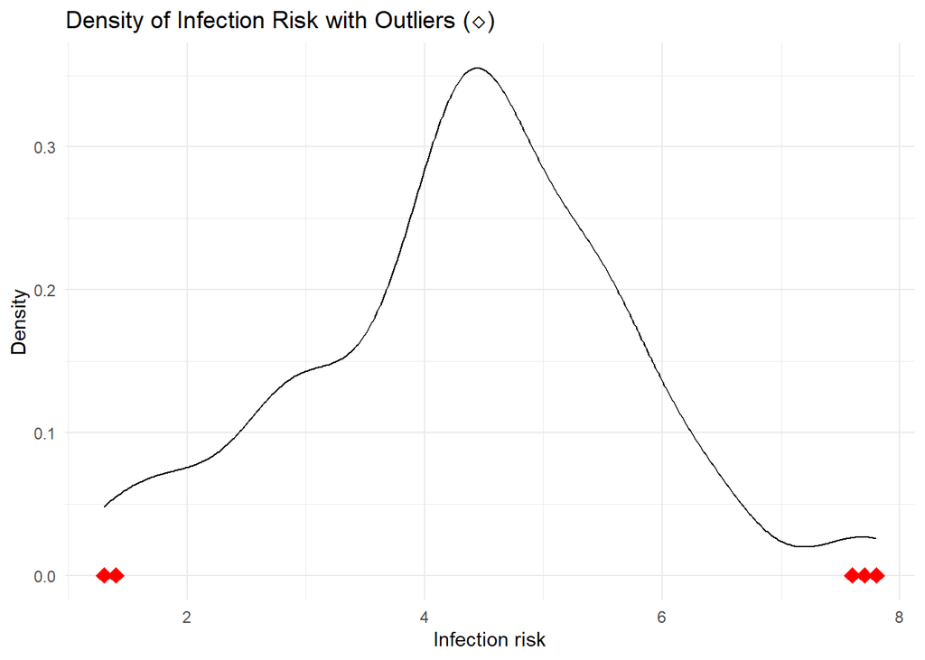

```r
infection_risk <- txt_f[,4]
outliers <- func1(infection_risk)
df <- data.frame(
  infection_risk = infection_risk,
  outlier = FALSE
)
df$outlier[outliers] <- TRUE

p3 <- ggplot(df, aes(x = infection_risk)) +
  geom_density() +
  geom_point(
    data = subset(df, outlier),
    aes(x = infection_risk, y = 0),
    shape = 23, size = 3, color = "red", fill = "red"
  ) +
  labs(x = "Infection risk", y = "Density",
       title = "Density of Infection Risk with Outliers (◇)") +
  theme_minimal()
p3
```

Most hospitals are in the medium risk range, but there are still a few hospitals that show extreme high risk or low risk.

## Density plot of all quantitative variables

```r
#' Function of density plot within a given variable
#'
#' @param df Dataset of SENIC
#' @param column A vector of variable
#' @param bw_adj chosen bw
#'
#' @returns Density plot with outliers

var_name <- c("Length of Stay","Age","Infection Risk","Routine Culturing Ratio",
              "Routine Chest X-ray Ratio","Number of Beds","Medical School Affiliation","Region","Average Daily Census",
              "Number of Nurses","Available Facilities & Services")

plot_func <- function(df, column, bw_adj = 1) {
  values <-  df[,colnames(df)==column]
  number_var <- which(colnames(df)==column)
  outliers <- func1(values)
  plot_df <- data.frame(
    value = values,
    outlier = rep(FALSE, length(values))
  )
  plot_df$outlier[outliers] <- TRUE

  p <- ggplot(plot_df, aes(x = value)) +
    geom_density(fill = "lightblue", alpha = 0.5, adjust = bw_adj) +
    geom_point(
      data = subset(plot_df, outlier),
      aes(x = value, y = 0),
      shape = 23, size = 2.5, color = "red", fill = "red"
    ) +
    labs(title = paste("Density of", var_name[number_var-1])) +
    theme_minimal()

  return(p)
}
```

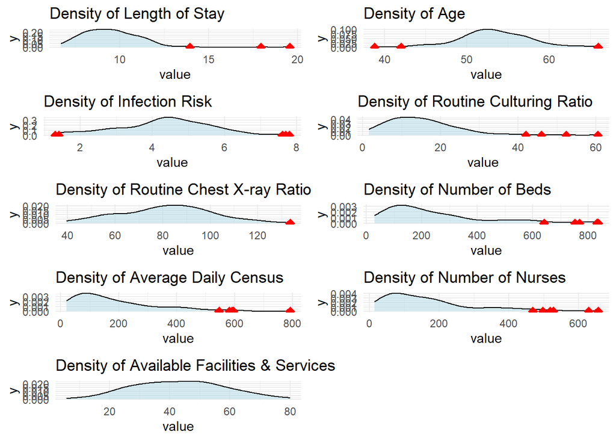

```r
all_vars <- paste0("V", c(2:7,10:12))
plots <- lapply(all_vars, function(v) plot_func(txt_f, v))

grid.arrange(grobs = plots, ncol = 2)
```

## Dependence of Infection risk on the Number of Nurses

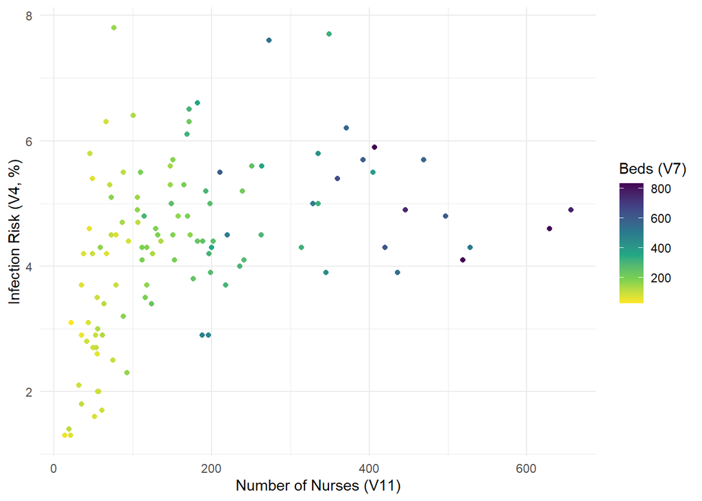

```r
ggplot(txt_f, aes(x = V11, y = V4, color = V7)) +
  geom_point() +
  scale_color_viridis_c(name = "Beds (V7)",direction = -1) +
  labs(x = "Number of Nurses (V11)", y = "Infection Risk (V4, %)") +
  theme_minimal()
```

The density plot in Step 4 only shows the individual distribution and outliers of each variable. But this scatter plot reveals an interactive relationship: the number of nurses and the number of beds are highly correlated. Also with the same number of nurses, hospitals of different sizes have different infection risks.

### Possible dangers of having such a color scale

The number of beds and the number of nurses actually provide similar information, namely the size of the hospital, so the number of nurses and the number of beds are strongly correlated. But the color gradient here can mislead people about the impact of the number of beds on the risk of infection.

Next, we Convert the graph from step 3 to Plotly with the ggplotly function.

```r
ggplotly(p3)
```

[interactive chart not shown]

New Plotly functionalities:  
1.Detailed information: Detailed information for data can be obtained by hovering the mouse over chart elements.  
2.A toolbar in the top-right corner provides functions like zooming.  
Analysis: The graph reveals extreme outliers at values of 1.3 and 7.8. These outliers, despite being few, notably expand the overall range of infection risk.

## Histogram of Infection risk

```r
library(dplyr)

out_idx  <- func1(txt_f$V4)
df7 <- txt_f %>%
  dplyr::select(id = V1, infection_risk = V4) %>%
  mutate(outlier = is.element(id, out_idx))

plot7 <- df7 %>% plot_ly() %>% add_histogram(x=~infection_risk, nbinsx=50, name="infection risk") %>%
  add_markers(data = df7 %>% filter(outlier),
              x=~infection_risk,y=0,
              name="outliers",
              marker = list(symbol = "diamond",
                            size = 10, color = "red"))
plot7
```

[interactive chart not shown]

## Shiny app

To make the Shiny app interactive, the code for it can be seen in the `shiny.R` file.

# Assignment 2

## Load Swedish map and data

First, we download Swedish map and required data from the website. Using `reshape()`to process the raw data,in which different age groups are shown in columns.

```r
#load and process data
data <- read.csv("income2023.csv",fileEncoding = "latin1")

data_reshape <- reshape(data,
                        idvar = "region",
                        timevar = "age",
                        direction="wide")
colnames(data_reshape) <- c("region","young","adult","senior")

#load the map

library(rjson)
json<-fromJSON(file="gadm41_SWE_1.json")
data_reshape
```

```
##                       region young adult senior
## 1        01 Stockholm county 450.4 775.2  902.5
## 4          03 Uppsala county 337.2 631.2  714.7
## 7     04 Södermanland county 389.5 588.5  638.2
## 10    05 Östergötland county 346.1 601.4  667.3
## 13       06 Jönköping county 390.0 619.8  701.9
## 16       07 Kronoberg county 356.6 605.8  673.9
## 19          08 Kalmar county 369.4 576.1  626.4
## 22         09 Gotland county 370.5 589.3  640.5
## 25        10 Blekinge county 366.5 585.0  631.0
## 28           12 Skåne county 375.5 630.0  715.2
## 31         13 Halland county 406.9 687.7  792.8
## 34 14 Västra Götaland county 398.5 631.7  715.0
## 37        17 Värmland county 351.1 578.0  618.7
## 40          18 Örebro county 357.2 574.6  631.5
## 43     19 Västmanland county 396.5 597.4  656.2
## 46         20 Dalarna county 388.5 574.7  610.5
## 49       21 Gävleborg county 367.4 555.9  596.9
## 52  22 Västernorrland county 367.5 571.6  623.0
## 55        23 Jämtland county 359.2 583.0  625.8
## 58    24 Västerbotten county 343.5 583.3  662.3
## 61      25 Norrbotten county 385.4 605.2  636.9
```

## Including Plots

Now we use `Ploty pipline` to show the mean income distributions for each age group.

```r
agePlot <- data%>%
  group_by(age)%>%
  plot_ly(x=~age,
          y=~X2023,
          type = "violin",
          box=list(visible=TRUE),
          meanline=list(visible=TRUE))%>%
  layout(
    xaxis=list(title="Age Group"),
    yaxis=list(title="Income Distribution")
  )
agePlot
```

[interactive chart not shown]

The plot shows that young people (18–29 years) have the lowest mean income (374.92), likely due to limited work experience. Seniors have the highest mean income (670.53), but the difference compared to adults (606.92) is relatively small, possibly reflecting that many adults are already in peak earning years. Senior incomes vary widely, from 596.9 to 902.5, which may be influenced by differences in earnings across industries as well as variations in pension and retirement income. In contrast, young people’s incomes show the smallest variation, likely because entry-level salaries tend to be relatively uniform across industries.

# Surface plot showing the Dependence of Senior Incomes on Adult and Young Incomes

We create a surface plot to show the dependence of Senior incomes on Adult and Young incomes in various counties.

```r
library(akima)
attach(data_reshape)
surface=interp(young,adult,senior,duplicate = "mean")
detach(data_reshape)

seniorIncomes <- plot_ly(
         x=~surface$x,
         y=~surface$y,
         z=~surface$z,
         type = 'surface')%>%
  layout(
 scene=list(xaxis=list(title="Young Incomes"),
         yaxis=list(title="Adult Incomes"),
         zaxis=list(title="Senior Incomes")
        )
  )

seniorIncomes
```

[interactive chart not shown]

The surface plot shows an upward trending,which indicates a positive correlation between senior incomes and both adult and young incomes across counties.It mainly shows that counties with higher adult and young incomes also tend to have higher senior incomes.

A linear regression model could be used to model this dependence since the upward trend is smooth, monotonic and without complex surface.However it is still necessary to check the residuals to confirm the relationship is linear.

## Choropleth Map Comparison of Young and Adult Incomes Across Counties

To visualize the spatial distribution, we first clean the `region` column in the dataset to match the corresponding field in the GeoJSON file.

```r
library(dplyr)
library(stringr)

#clean the 'region' column so it matches the GeoJSON NAME_1
data_reshape <- data_reshape%>%
  mutate(
    region_clean=str_remove(region,"^[0-9]+\\s+"),
    region_clean=str_remove(region_clean,"\\s+county$"),

    region_clean=case_when(
      region_clean == "Västra Götaland" ~ "VästraGötaland",
      region_clean == "Örebro" ~ "Orebro",
      TRUE~region_clean
    )
  )

g=list(fitbounds="locations", visible=TRUE,projection = list(type = "mercator"))
#young
young<-plot_geo(data_reshape)%>%add_trace(type="choropleth",geojson=json, locations=~region_clean,
                            z=~young, featureidkey="properties.NAME_1")%>%
    add_trace(
    type="scattergo",
    lon=c(15.62157),
    lat=c(58.41086),
    mode="markers+text",
    text="Link\u00F6ping",
    textposition="right",
    marker=list(size=8,color="red",cymbol="circle")
  )%>%
  layout(geo=g,
         title=list(text="Young people incomes by county in Sweden",
                    x=0.5,
                    xanchor="center"))
young
```

[interactive chart not shown]

```r
#adult
adult<-plot_geo(data_reshape)%>%add_trace(type="choropleth",geojson=json, locations=~region_clean,
                                          z=~adult, featureidkey="properties.NAME_1")%>%
  layout(geo=g,
         title=list(text="Adult incomes by county in Sweden",
                     x=0.5,
                     xanchor="center"))
adult
```

[interactive chart not shown]

## Add Linköping coordinates to the Young-income choropleth map

The coordinates of Linköping were added as a red marker with a label in the young income map shown above.

# Assignment 3

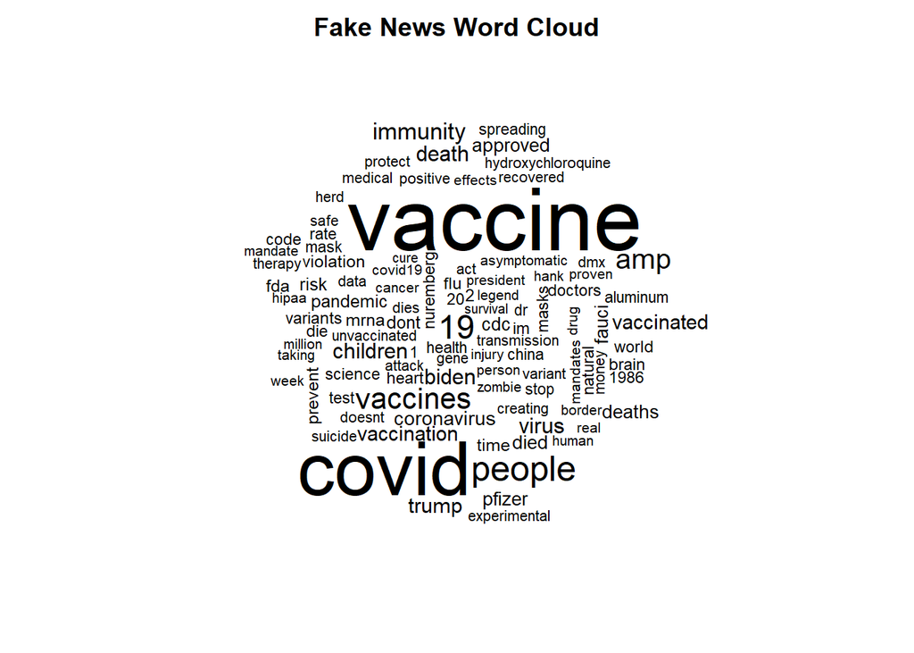

```r
data("stop_words")

data_clean <- data %>%
  unnest_tokens(word, tweet) %>%
  anti_join(stop_words, by = "word")

word_counts <- data_clean %>%
  count(label, word, sort = TRUE)

par(mar=c(0,0,2,0))

fake_words <- subset(word_counts, label == 0)
wordcloud(words = fake_words$word,
          freq = fake_words$n,
          max.words = 100)
title("Fake News Word Cloud")
```

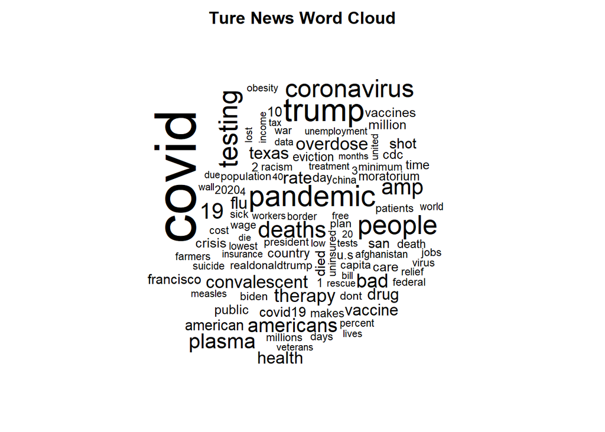

```r
par(mar=c(0,0,2,0))
true_words <- subset(word_counts, label == 1)
wordcloud(words = true_words$word,
          freq = true_words$n,
          max.words = 100)
title("Ture News Word Cloud")
```

*Fake news*: Vaccine and Covid are the two most mentioned words.

*True news*: Covid is the most mentioned word, followed by trump,pandemic and people.

# Sentiment analysis

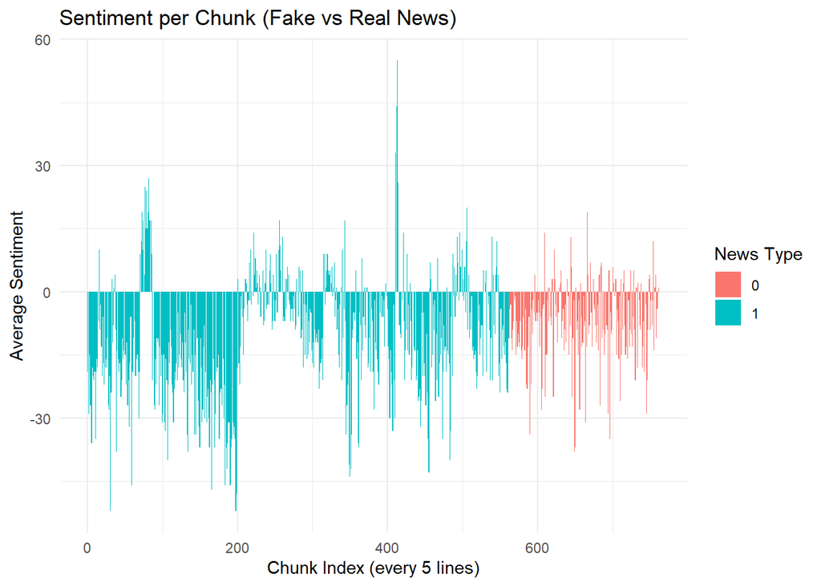

```r
afinn <- get_sentiments("afinn")

tweets_sent <- data %>%
  mutate(chunk = rep(1:ceiling(n()/5), each = 5, length.out = n())) %>%
  unnest_tokens(word, tweet) %>%
  inner_join(afinn, by = "word") %>%
  group_by(label, chunk) %>%
  summarise(sentiment = sum(value), .groups = "drop")


ggplot(tweets_sent, aes(x = chunk, y = sentiment, fill = factor(label))) +
  geom_col(position = "dodge") +
  labs(title = "Sentiment per Chunk (Fake vs Real News)",
       x = "Chunk Index (every 5 lines)",
       y = "Average Sentiment",
       fill = "News Type") +
  theme_minimal()
```

*Common ground*: The sum of sentiments for both True and Fake news is generally negative.

# Phrase nets

```r
make_phrase_net_vis <- function(data, connectors, news_type, min_freq = 1) {

  df <-data[data$label==news_type,]

  tidy_frame <- df %>%
    unnest_tokens(trigram, tweet, token = "ngrams", n = 3) %>%
    separate(trigram, into = c("word1", "word2", "word3"), sep = " ") %>%
    filter(word2 %in% connectors)

  tidy_frame <- tidy_frame %>%
    filter(!word1 %in% stop_words$word)%>%
    filter(!word3 %in% stop_words$word)


  edges <- tidy_frame %>%
    count(word1, word3, name = "width", sort = TRUE) %>%
    filter(width >= min_freq) %>%
    transmute(from = word1, to = word3, width, arrows = "to")

  right_words <- edges %>% count(word = to,   wt = width)
  left_words  <- edges %>% count(word = from, wt = width)

  nodes <- full_join(left_words, right_words, by = "word") %>%
    mutate(n.x = coalesce(n.x, 0),
           n.y = coalesce(n.y, 0),
           n.total = n.x + n.y,
           id = word, label = word, value = n.total) %>%
    filter(n.total >= 3)

  rnk <- rank(nodes$n.total, ties.method = "min", na.last = "keep")
  denom <- max(rnk, na.rm = TRUE); if (!is.finite(denom)) denom <- 1
  grp <- ifelse(is.na(rnk), 1L, pmax(1L, ceiling(rnk / denom * 9)))

  nodes$color <- brewer.pal(9, "Blues")[grp]
  nodes$`font.size` <- 25L

  nodes <- nodes %>% filter(id %in% edges$from | id %in% edges$to)

  visNetwork(nodes, edges)
}

connectors <- c("am", "is", "are", "was", "were")
```

```r
make_phrase_net_vis(data, connectors, 0,  min_freq = 1)
```

[interactive chart not shown]

**Fake news**:

The content of fake news mainly focuses on the topic of COVID. Fake news tends to highlight doubts and denials (masks are ineffective, immunity is reached, the CDC is lying), often in the form of short, emotional accusations.

```r
make_phrase_net_vis(data, connectors, 1,  min_freq = 1)
```

[interactive chart not shown]

**True news**: True news has more core nodes and is more complex, encompassing more topics beyond COVID. The nodes are highly connected, with many loops or intertwining patterns. This suggests that true news texts tend to be more comprehensive narratives.

# Appendix

## Assignment 1

```r
txt_f <- read.table("SENIC.txt", header = FALSE)

func1 <- function(column){

  quantiles <- quantile(column,probs=c(0.25,0.75))
  greater <- quantiles[2] + 1.5*(quantiles[2] - quantiles[1])
  less <- quantiles[1] - 1.5*(quantiles[2] - quantiles[1])

  ind1 <- which(column<less)
  ind2 <- which(column>greater)

  ind <- c(ind1,ind2)
  return(ind)
}

#step3
library(ggplot2)

infection_risk <- txt_f[,4]
outliers <- func1(infection_risk)
df <- data.frame(
  infection_risk = infection_risk,
  outlier = FALSE
)
df$outlier[outliers] <- TRUE

p3 <- ggplot(df, aes(x = infection_risk)) +
  geom_density() +
  geom_point(
    data = subset(df, outlier),
    aes(x = infection_risk, y = 0),
    shape = 23, size = 3, color = "red", fill = "red"
  ) +
  labs(x = "Infection risk", y = "Density",
       title = "Density of Infection Risk with Outliers (◇)") +
  theme_minimal()
p3


#step4
library(gridExtra)

var_name <- c("Length of Stay","Age","Infection Risk","Routine Culturing Ratio",
              "Routine Chest X-ray Ratio","Number of Beds","Medical School Affiliation","Region","Average Daily Census",
              "Number of Nurses","Available Facilities & Services")

plot_func <- function(df, column, bw_adj = 1) {
  values <-  df[,colnames(df)==column]
  number_var <- which(colnames(df)==column)
  outliers <- func1(values)
  plot_df <- data.frame(
    value = values,
    outlier = rep(FALSE, length(values))
  )
  plot_df$outlier[outliers] <- TRUE

  p <- ggplot(plot_df, aes(x = value)) +
    geom_density(fill = "lightblue", alpha = 0.5, adjust = bw_adj) +
    geom_point(
      data = subset(plot_df, outlier),
      aes(x = value, y = 0),
      shape = 23, size = 2.5, color = "red", fill = "red"
    ) +
    labs(title = paste("Density of", var_name[number_var-1])) +
    theme_minimal()

  return(p)
}


all_vars <- paste0("V", c(2:7,10:12))
plots <- lapply(all_vars, function(v) plot_func(txt_f, v))

grid.arrange(grobs = plots, ncol = 2)
#


#step5
ggplot(txt_f, aes(x = V11, y = V4, color = V7)) +
  geom_point() +
  scale_color_viridis_c(name = "Beds (V7)",direction = -1) +
  labs(x = "Number of Nurses (V11)", y = "Infection Risk (V4, %)") +
  theme_minimal()



#step6
library(plotly)
ggplotly(p3)


#step7
library(dplyr)
out_idx  <- func1(txt_f$V4)
df7 <- txt_f %>%
  select(id = V1, infection_risk = V4) %>%
  mutate(outlier = is.element(id, out_idx))

plot7 <- df7 %>% plot_ly() %>% add_histogram(x=~infection_risk, nbinsx=50, name="infection risk") %>%
  add_markers(data = df7 %>% filter(outlier),
              x=~infection_risk,y=0,
              name="outliers",
              marker = list(symbol = "diamond",
                            size = 10, color = "red"))
plot7
#step8
library(shiny)

ui <- fluidPage(
  titlePanel("Densities"),
  sidebarLayout(
    sidebarPanel(
      checkboxGroupInput(
        "vars", "choose variables（V2–V12）：",
        choices = paste0("V", 2:12),
        selected = c("V4", "V2", "V11")
      ),
      sliderInput(
        "bw_adj", "bw：",
        min = 0.3, max = 3, value = 1, step = 0.1
      )
    ),
    mainPanel(
      plotOutput("panel", height = "720px")
    )
  )
)

server <- function(input, output, session){

  output$panel <- renderPlot({
    req(input$vars)

    plots <- lapply(
      input$vars,
      function(v) plot_func(txt_f, v, bw_adj = input$bw_adj)
    )

    do.call(grid.arrange, c(plots, ncol = input$ncol))
  })
}
shinyApp(ui, server)
```

# Assignment 2

```r
#1
library(tidyr)
#load and process data
data <- read.csv("income2023.csv",fileEncoding = "latin1")

data_reshape <- reshape(data,
                        idvar = "region",
                        timevar = "age",
                        direction="wide")
colnames(data_reshape) <- c("region","young","adult","senior")

#load the map

library(rjson)
json<-fromJSON(file="gadm41_SWE_1.json")

#2
library(plotly)



agePlot <- data%>%
  group_by(age)%>%
  plot_ly(x=~age,
          y=~X2023,
          type = "violin",
          box=list(visible=TRUE),
          meanline=list(visible=TRUE))%>%
  layout(
    xaxis=list(title="Age Group"),
    yaxis=list(title="Income Distribution")
  )
agePlot

#3Surface plot
library(akima)
attach(data_reshape)
surface=interp(young,adult,senior,duplicate = "mean")
detach(data_reshape)

seniorIncomes <- plot_ly(
         x=~surface$x,
         y=~surface$y,
         z=~surface$z,
         type = 'surface')%>%
  layout(
 scene=list(xaxis=list(title="Young Incomes"),
         yaxis=list(title="Adult Incomes"),
         zaxis=list(title="Senior Incomes")
        )
  )

seniorIncomes





#4&5
library(dplyr)
library(stringr)

#clean the 'region' column so it matches the GeoJSON NAME_1
data_reshape <- data_reshape%>%
  mutate(
    region_clean=str_remove(region,"^[0-9]+\\s+"),
    region_clean=str_remove(region_clean,"\\s+county$"),

    region_clean=case_when(
      region_clean == "Västra Götaland" ~ "VästraGötaland",
      region_clean == "Örebro" ~ "Orebro",
      TRUE~region_clean
    )
  )

g=list(fitbounds="locations", visible=TRUE,projection = list(type = "mercator"))
#young
young<-plot_geo(data_reshape)%>%add_trace(type="choropleth",geojson=json, locations=~region_clean,
                            z=~young, featureidkey="properties.NAME_1")%>%
  add_trace(
    type="scattergo",
    lon=c(15.62157),
    lat=c(58.41086),
    mode="markers+text",
    text="Link\u00F6ping",
    textposition="right",
    marker=list(size=8,color="red",cymbol="circle")
  )%>%
  layout(geo=g,
         title=list(text="Young people incomes by county in Sweden",
                    x=0.5,
                    xanchor="center"))
young
#adult
adult<-plot_geo(data_reshape)%>%add_trace(type="choropleth",geojson=json, locations=~region_clean,
                                          z=~adult, featureidkey="properties.NAME_1")%>%
  layout(geo=g,
         title=list(text="Adult incomes by county in Sweden",
                     x=0.5,
                     xanchor="center"))
adult
```

# Assignment 3

```r
library(dplyr)
library(tidytext)
library(wordcloud)
library(textdata)
library(ggraph)
library(igraph)
library(tidyr)
library(stringr)
library(RColorBrewer)
library(visNetwork)

data <- read.csv("tweets.csv")

data("stop_words")

data_clean <- data %>%
  mutate(label = ifelse(label == 0, "Fake", "True")) %>%
  unnest_tokens(word, tweet) %>%
  anti_join(stop_words, by = "word")

word_counts <- data_clean %>%
  count(label, word, sort = TRUE)

par(mfrow=c(1,2))

fake_words <- subset(word_counts, label == "Fake")
wordcloud(words = fake_words$word,
          freq = fake_words$n,
          max.words = 100)
title("Fake News Word Cloud")

true_words <- subset(word_counts, label == "True")
wordcloud(words = true_words$word,
          freq = true_words$n,
          max.words = 100)
title("Ture News Word Cloud")

#step2
afinn <- get_sentiments("afinn")

tweets_sent <- data %>%
  mutate(chunk = rep(1:ceiling(n()/5), each = 5, length.out = n())) %>%
  unnest_tokens(word, tweet) %>%
  inner_join(afinn, by = "word") %>%
  group_by(label, chunk) %>%
  summarise(sentiment = mean(value), .groups = "drop")


ggplot(tweets_sent, aes(x = chunk, y = sentiment, fill = factor(label))) +
  geom_col(position = "dodge") +
  labs(title = "Sentiment per Chunk (Fake vs Real News)",
       x = "Chunk Index (every 5 lines)",
       y = "Average Sentiment",
       fill = "News Type") +
  theme_minimal()


#step3


make_phrase_net_vis <- function(data, connectors, news_type, min_freq = 1) {

  df <-data[data$label==news_type,]

  tidy_frame <- df %>%
    unnest_tokens(trigram, tweet, token = "ngrams", n = 3) %>%
    separate(trigram, into = c("word1", "word2", "word3"), sep = " ") %>%
    filter(word2 %in% connectors)

  tidy_frame <- tidy_frame %>%
    filter(!word1 %in% stop_words$word)%>%
    filter(!word3 %in% stop_words$word)


  edges <- tidy_frame %>%
    count(word1, word3, name = "width", sort = TRUE) %>%
    filter(width >= min_freq) %>%
    transmute(from = word1, to = word3, width, arrows = "to")

  right_words <- edges %>% count(word = to,   wt = width)
  left_words  <- edges %>% count(word = from, wt = width)

  nodes <- full_join(left_words, right_words, by = "word") %>%
    mutate(n.x = coalesce(n.x, 0),
           n.y = coalesce(n.y, 0),
           n.total = n.x + n.y,
           id = word, label = word, value = n.total) %>%
    filter(n.total >= 3)

  rnk <- rank(nodes$n.total, ties.method = "min", na.last = "keep")
  denom <- max(rnk, na.rm = TRUE); if (!is.finite(denom)) denom <- 1
  grp <- ifelse(is.na(rnk), 1L, pmax(1L, ceiling(rnk / denom * 9)))

  nodes$color <- brewer.pal(9, "Blues")[grp]
  nodes$`font.size` <- 25L

  nodes <- nodes %>% filter(id %in% edges$from | id %in% edges$to)

  visNetwork(nodes, edges)
}

connectors <- c("am", "is", "are", "was", "were")

make_phrase_net_vis(data, connectors, 0,  min_freq = 2)

make_phrase_net_vis(data, connectors, 1,  min_freq = 2)
```